# Homework 4

Ahmed_Drammeh

4/19/2021

## Obesity Hospitalization Data in England

This dataset contains informaion regarding **finished admissions episodes** (FAE) for people in the United Kingdom who were admitted due to obesity issues. The dataset in particular is part of a larger grouped dataset on the same excel sheet, and requires tedious navigation inorder to separate the **FAE** information from the other redundant tables. The **FAE** episodes involving obese patients are categorized into age groups ranging from:

- Under 16
- 16 - 24
- 25 - 34
- 35 - 44
- 45 - 54
- 55 - 64
- 65 - 74
- 75 & Over

Furthermore, these hospitalizations were recorded from 2002-2003 fiscal year all the way through 2012-2013. On the RAW excel spreadsheet, the dataset can be identified as *Table 7.2: Finished Admission Episodes with a primary diagnosis of obesity, by age group, 2002/03 to 2012/13* Inorder for any data analysis to be performed on the obesity information, the data had to be cleaned first. The data was imported into R-studio by skipping the first 37 rows of the spreadsheet, since these rows include data from **Table 7.1**, and not **7.2**. Apart from skipping the first 37 rows, the number of rows containing the data of interest had to be inputed within the read.csv file, and is inlcuded within the script. There are 13 rows and 12 columns within the dataset. The next paragraph describes the data cleaning and tidying effort:

## Data cleaning & tidying

The imported medical obesity dataset was poorly organized and the column and row names needed to be tidied and renamed. There are two ways to approach this. The first is with conventional R methodolgies of assigning new column names to an object, for example in our case( col.names), and then use this new object as an argument within the **names()** function to rename the column. The sequence of scripts below show this relationship. The second approach utilizes the **DPYLR** package, specifically the *rename()*, *select()*, and *slice()* functions to change the column names while also removing unnecessary empty rows. The second approach combined with the pipe operator makes for a much easier tidying method. The dataset can be further tidied, by removing organizing the different ages into one column called *Age groups*,making it both ore visually appealing to look at aswell as easier for statistical analysis. Under the tidyverse package, the **gather()** is a great function to help consodlidate data from wide to long format, and that has been utilized in this portion of the data tidying. Utilizing the gather function helped change the data format from wide to long, while also removing all the *NA* values which were present.

```r
library(tidyverse)
library(dplyr)

Obesity1<- read.csv("obes-phys-acti-diet-eng-2014-tab_csv.csv",header =TRUE, stringsAsFactors= FALSE, skip=37, nrows= 13)
str(Obesity1)
```

```
## 'data.frame':    13 obs. of  12 variables:
##  $ X           : chr  "" "2002/03" "2003/04" "2004/05" ...
##  $ Total       : chr  "" "1,275" "1,711" "2,035" ...
##  $ Under.16    : int  NA 400 579 547 583 656 747 775 632 525 ...
##  $ X16.24      : int  NA 65 67 107 96 184 228 322 361 375 ...
##  $ X25.34      : chr  "" "136" "174" "287" ...
##  $ X35.44      : chr  "" "289" "391" "487" ...
##  $ X45.54      : chr  "" "216" "273" "364" ...
##  $ X55.64      : chr  "" "94" "151" "174" ...
##  $ X65.74      : int  NA 52 52 36 72 118 157 221 378 456 ...
##  $ X75.and.over: int  NA 23 24 32 20 43 53 63 87 115 ...
##  $ X.1         : logi  NA NA NA NA NA NA ...
##  $ X.2         : logi  NA NA NA NA NA NA ...
```

```r
colnames(Obesity1)
```

```
##  [1] "X"            "Total"        "Under.16"     "X16.24"
##  [5] "X25.34"       "X35.44"       "X45.54"       "X55.64"
##  [9] "X65.74"       "X75.and.over" "X.1"          "X.2"
```

```r
Obesity2<-Obesity1 %>% rename(Fiscal_Year= X, "Under 16" = Under.16,
                             "16 to 24"= X16.24, "25 to 34" = X25.34,
                             "35 to 44" = X35.44,"45 to 54" = X45.54,
                             "55 to 64" = X55.64,"65 to 74" = X65.74,
                             "75 & Over" = X75.and.over) %>%
  select(1:10) %>% slice(-1)
Obesity3<-Obesity2%>%
  slice(-12) %>%
  gather(key="Age_Groups", value="Obesity_cases", -1,-2, na.rm=TRUE)

## Used global substitution function to change the character strings into numeric inroder to analyze them. dplyr as.numeric did not work well with numbers withi rows that have a comma(,) in them i.e.2,567

Obesity3$Total<-as.numeric(as.character(gsub(",", "",Obesity3$Total)))
Obesity3$Obesity_cases<-as.numeric(as.character(gsub(",", "",Obesity3$Obesity_cases)))
```

## Descriptive statistics

The scripts below show some statistical analysis of the Obesity hospitalization data. The major findings include measuremenets of central tendancy (**mean**, **standard deviation** and **coefficient of variation**), aswell as some 5 number summary including the **min**, **max** and **median**. Looking at the overall data from a global perspective, it can be seen that the age groups **35-44 & 45-54** have the highest number of hospitalizations per year due to obesity( **Max = 3277 & 3581, and on average = 1723 & 1740**) over the time frames between *2002/2003* - *2012/2013*. This makes sense, since metabolic rates diminish significantly around those ages. Also people tend to be married and care less about what they eat or look like arounfd those ages. The age groups with the lowest hospitalizations and obesity rates are **75 & Over( max = 115 and on average = 59)**.

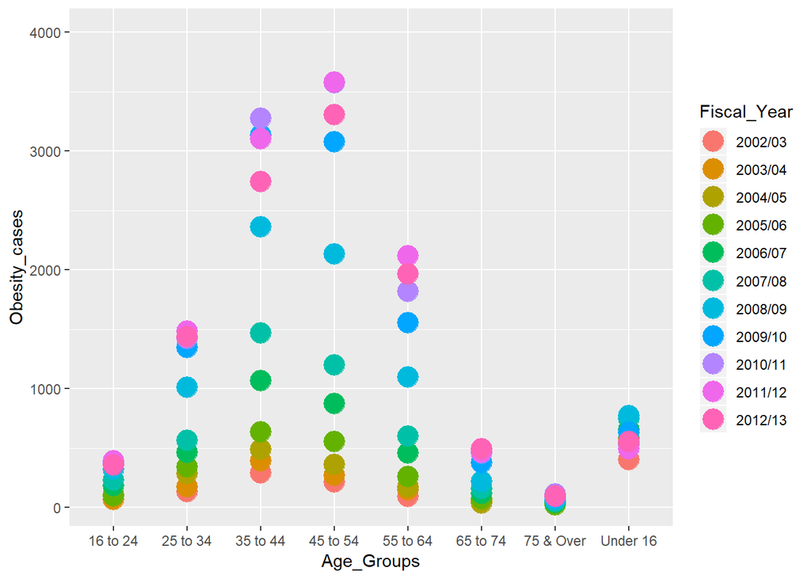

```r
library(tidyverse)
Obesity3 %>%
  ggplot(aes(y=Obesity_cases, x=Age_Groups, color=Fiscal_Year)) + geom_point(size=6) +coord_cartesian(ylim=c(40,4000))
```

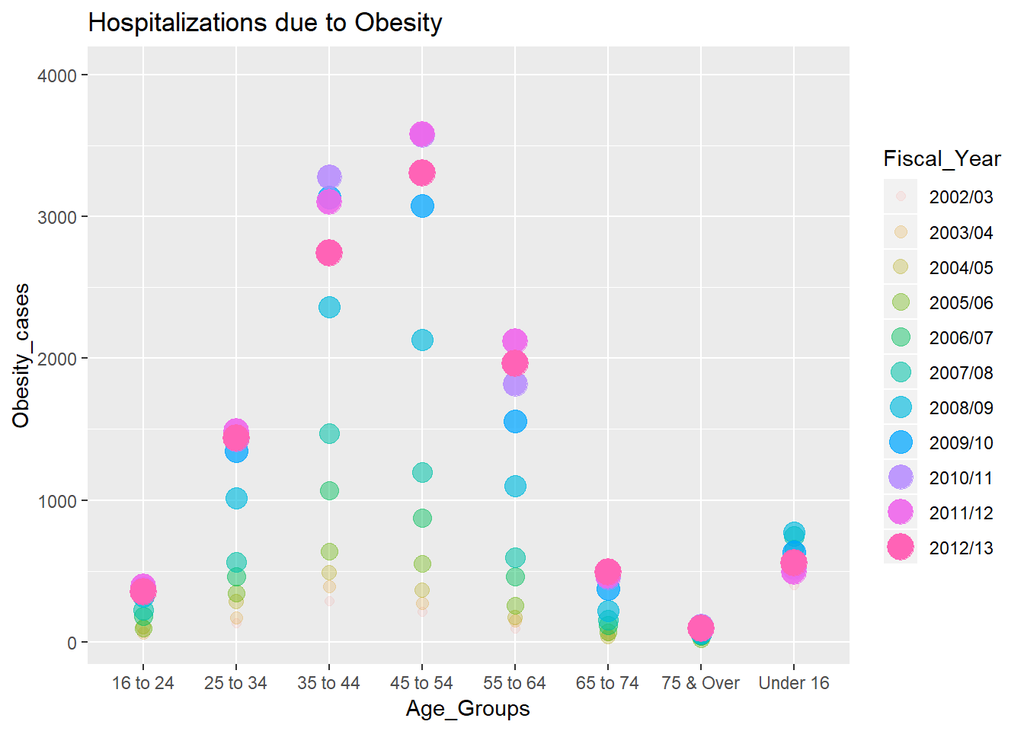

```r
## Changing the size and tranparency of the marker's help magnify the impact of the fiscal year on Obesity hospitalizations.

Obesity3 %>%
  ggplot(aes(y=Obesity_cases, x=Age_Groups, size=Fiscal_Year,color=Fiscal_Year, alpha=Fiscal_Year)) + geom_point() +coord_cartesian(ylim=c(40,4000)) + ggtitle("Hospitalizations due to Obesity")
```

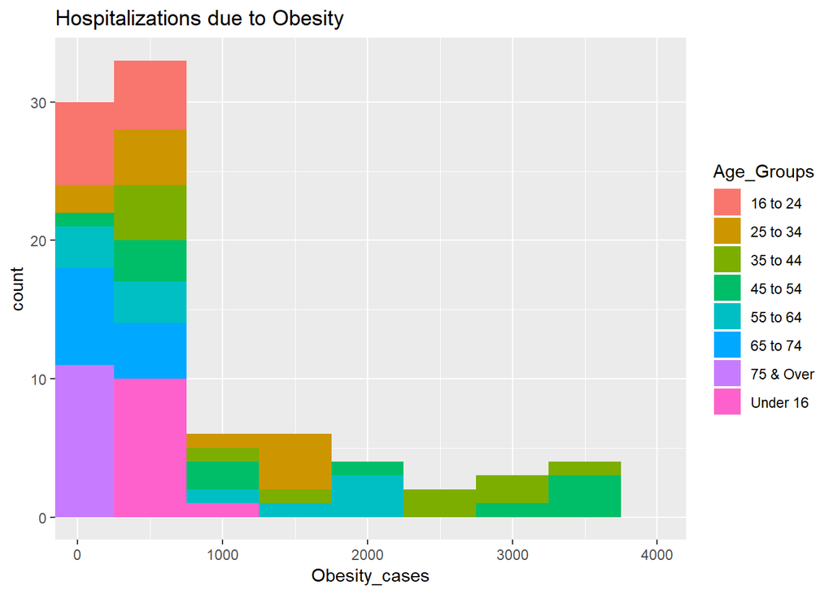

```r
## Histogram does not do a good job of easily discriminating between the Age groups.

Obesity3 %>%
  ggplot(aes(x =Obesity_cases, fill=Age_Groups )) + geom_histogram(binwidth = 500) + coord_cartesian(xlim=c(40,4000)) + ggtitle("Hospitalizations due to Obesity")
```

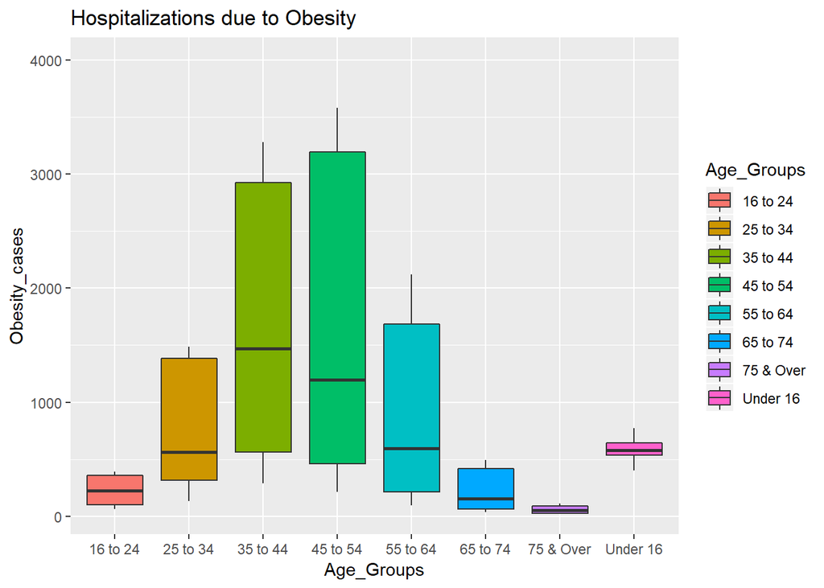

```r
## Boxplots are another means to decribe the data in a way that helps easily visualize trends.

Obesity3 %>%
  ggplot(aes(y =Obesity_cases, x=Age_Groups, fill=Age_Groups )) + geom_boxplot() + coord_cartesian(ylim=c(40,4000)) + ggtitle("Hospitalizations due to Obesity")
```

```r
Obesity4<-Obesity3 %>%
  group_by(Age_Groups) %>%
  summarise(Obesity_Min = min(Obesity_cases),
            Obesity_mean = round(mean(Obesity_cases)),
            Obesity_max = max(Obesity_cases),
            Std.dev = sd(Obesity_cases)) %>%
  mutate(COV = round((Std.dev/Obesity_mean),digits =2))
head(Obesity4)
```

```
## # A tibble: 6 x 6
##   Age_Groups Obesity_Min Obesity_mean Obesity_max Std.dev   COV
##   <chr>            <dbl>        <dbl>       <dbl>   <dbl> <dbl>
## 1 16 to 24            65          232         391    133. 0.570
## 2 25 to 34           136          788        1484    555. 0.7
## 3 35 to 44           289         1723        3277   1216. 0.71
## 4 45 to 54           216         1740        3581   1413. 0.81
## 5 55 to 64            94          936        2119    797. 0.85
## 6 65 to 74            36          228         495    185. 0.81
```

```r
## To keep to the original format of the data, i assigned a sorting mechanism to an object called *reorder*, and then used the slice(match()) functions to rearrange them in my desired order. R naturally arranges rows based on numerics first, and strings second.
reorder<-c("Under 16", "16 to 24", "25 to 34", "35 to 44", "45 to 54", "55 to 64", "65 to 74", "75 & Over")
Obesity4%>% slice(match(reorder, Age_Groups))
```

```
## # A tibble: 8 x 6
##   Age_Groups Obesity_Min Obesity_mean Obesity_max Std.dev   COV
##   <chr>            <dbl>        <dbl>       <dbl>   <dbl> <dbl>
## 1 Under 16           400          590         775   108.  0.18
## 2 16 to 24            65          232         391   133.  0.570
## 3 25 to 34           136          788        1484   555.  0.7
## 4 35 to 44           289         1723        3277  1216.  0.71
## 5 45 to 54           216         1740        3581  1413.  0.81
## 6 55 to 64            94          936        2119   797.  0.85
## 7 65 to 74            36          228         495   185.  0.81
## 8 75 & Over           20           59         115    34.4 0.580
```

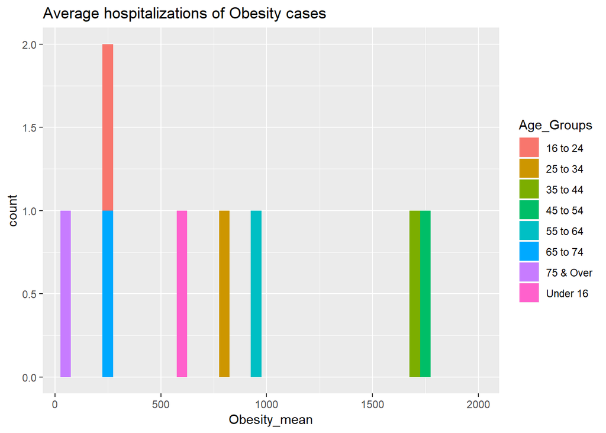

```r
## Use of a histogram however, does a good job of showing the differences in Age groups when the data is summarized using measures of central tendancy.

## Average numer of obesity hospitalization when the fiscal year is lumped together.
Obesity4 %>%
  ggplot(aes(x =Obesity_mean, fill=Age_Groups, group=Age_Groups )) + geom_histogram(binwidth = 50) + coord_cartesian(xlim=c(40,2000)) + ggtitle("Average hospitalizations of Obesity cases")
```

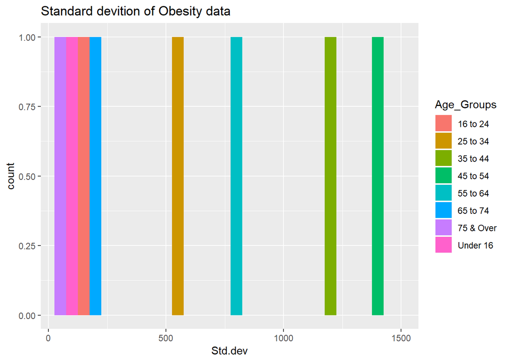

```r
## Standard deviation of the hospitalization rate.

Obesity4 %>%
  ggplot(aes(x =Std.dev, fill=Age_Groups, group=Age_Groups )) + geom_histogram(binwidth = 50) + coord_cartesian(xlim=c(40,1500)) + ggtitle("Standard devition of Obesity data")
```

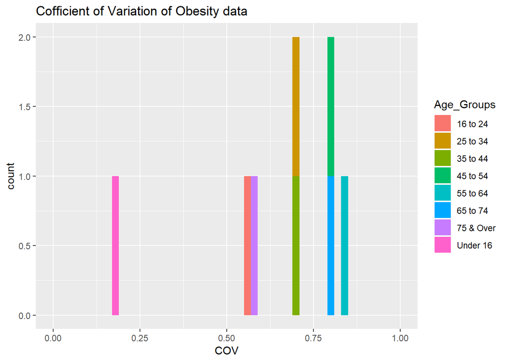

```r
## Coefficient of variation the hospitalization rate.

Obesity4 %>%
  ggplot(aes(x =COV, fill=Age_Groups, group=Age_Groups )) + geom_histogram(binwidth = .02) + coord_cartesian(xlim=c(0,1)) + ggtitle("Cofficient of Variation of Obesity data")
```

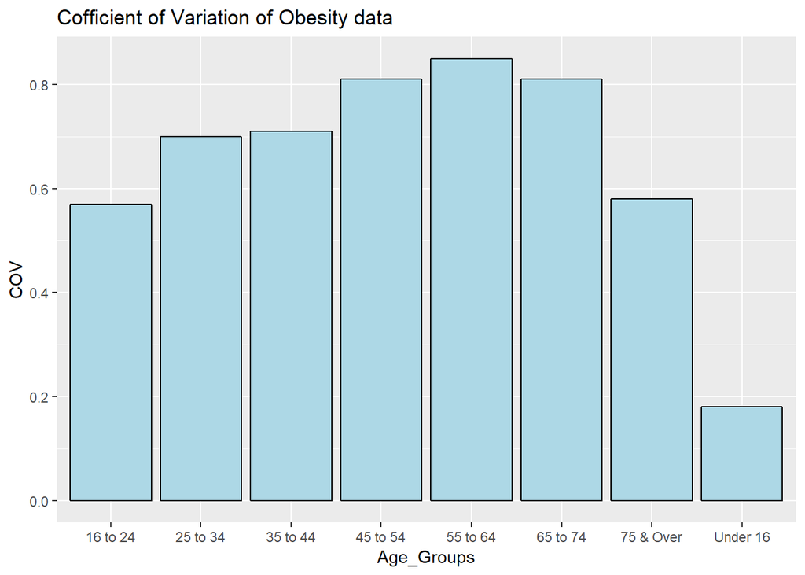

```r
## Perhaps the best representation of the summaried data can be described in the form of a barplot or a boxplot

Obesity4 %>%
  ggplot(aes(x=Age_Groups, y=COV)) +geom_bar(stat="identity", color="black", fill="light blue") + ggtitle("Cofficient of Variation of Obesity data")
```

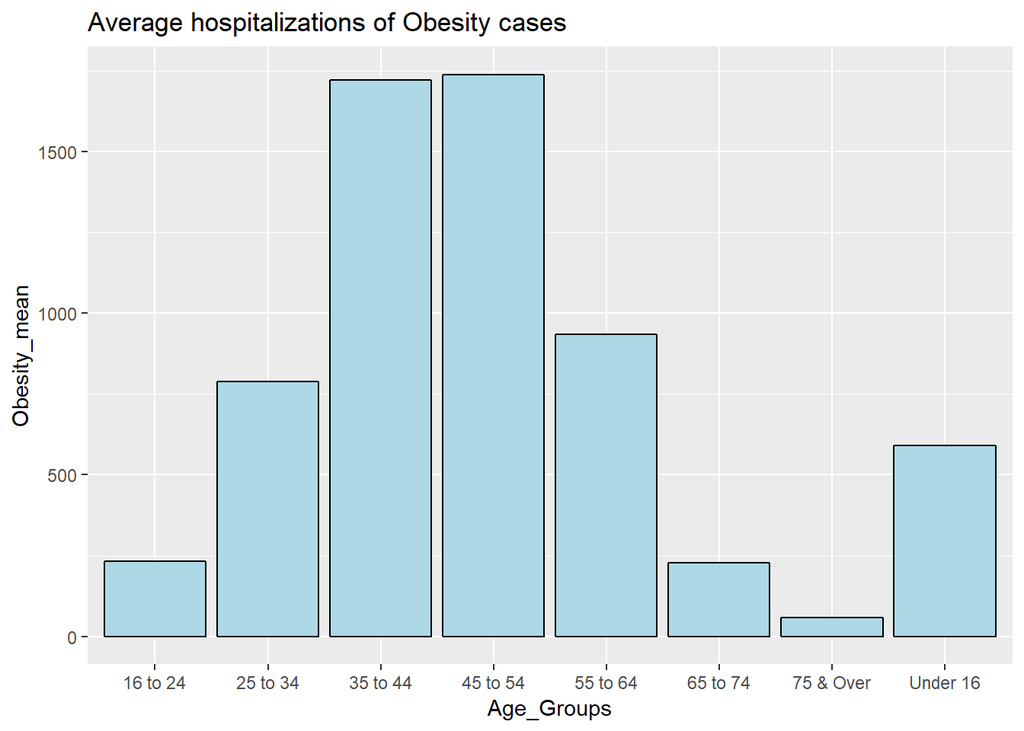

```r
## Avergae number of hospitalizations

Obesity4 %>%
  ggplot(aes(x=Age_Groups, y=Obesity_mean)) +geom_bar(stat="identity", color="black", fill="light blue") +  ggtitle("Average hospitalizations of Obesity cases")
```